# PubH_7462_HW2_Shen0464

You Shan Shen

2022/2/6

3.1 Data Exploration & Cleaning (10pts)

3.2 Data Description (10pts)

```r
number_row <- brfss_smart_df %>% nrow()
number_col <- brfss_smart_df %>% ncol()
year_level <- length(unique(brfss_smart_df$year))
response_level <- length(unique(brfss_smart_df$response))
number_state <- length(unique(brfss_smart_df$state))
number_county <- length(unique(brfss_smart_df$county))
```

2002-2010. BRFSS SMART County Prevalence contains 10625 observations and 6 variables. Each observation is defined as a data about a U.S. resident regarding their health-related risk behaviors, chronic health conditions, and use of preventive services.

The definition of variables in 3.1:

Year: The survey conduct in 9 different numbers of year.

Response: There are 5 levels response from an observation.

State: Observations are from 51 different states in US.

Sample size: the number of sample from a specific year, response, state, and county.

Proportion of response: the proportion of sample from a specific level of response according to year, state, and county in percentage.

3.3 Do Data Science (50pts) 3.3.1 In the year 2004, which states were observed at 6 locations? (10pts)

```r
library(gt)

brfss_smart_df %>%
  filter(year %in% '2004') %>%
  dplyr::select( state, county ) %>%
  group_by( state) %>%
  distinct( county , .keep_all = TRUE) %>%
  summarize(n = n() ) %>%
  filter(n == 6) %>%
  gt()
```

| state | n |
| --- | --- |
| CO | 6 |
| CT | 6 |
| MD | 6 |
| NM | 6 |
| SC | 6 |
| TX | 6 |
| UT | 6 |
| VT | 6 |

3.3.2 Make a “spaghetti plot” that shows the number of observed locations in each state from 2002 to 2010. Which state has the highest mean number of locations over this period? (10pts)

```r
library(ggplot2)
library(viridis)
library(forcats)

brfss_smart_spa <- brfss_smart_df %>%
  group_by(state, year) %>%
  distinct(state, year, county) %>%
  summarize(number = n() )
brfss_smart_spa$state1 <- fct_reorder(brfss_smart_spa$state,brfss_smart_spa$number,mean ,  na.rm = TRUE, .desc = TRUE)
levels(brfss_smart_spa$state1)
```

```
##  [1] "NJ" "FL" "NC" "WA" "MD" "MA" "TX" "NY" "SC" "CO" "OH" "PA" "NE" "CA" "UT"
## [16] "NH" "VT" "CT" "LA" "NM" "OK" "KS" "RI" "VA" "HI" "GA" "MI" "MN" "OR" "AZ"
## [31] "ID" "ME" "DE" "TN" "IL" "MO" "MT" "MS" "WY" "AR" "IN" "AL" "ND" "NV" "SD"
## [46] "AK" "IA" "DC" "KY" "WI" "WV"
```

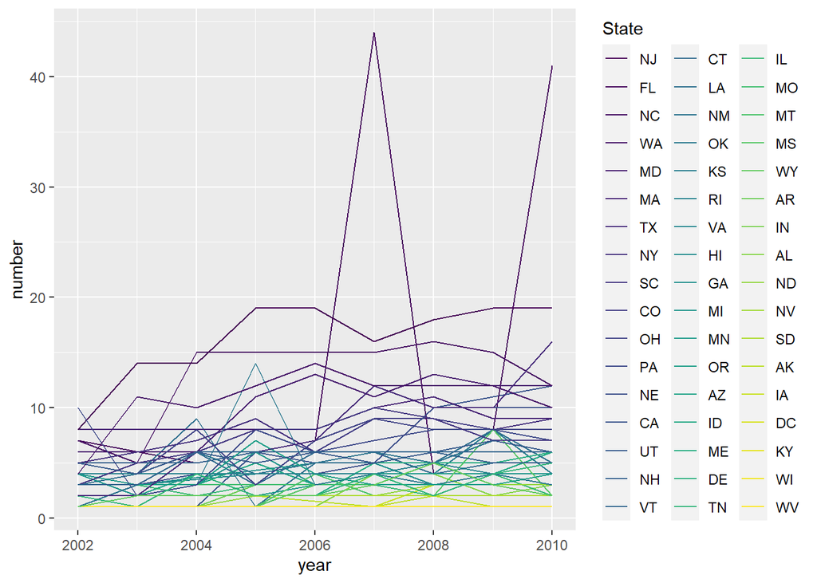

```r
brfss_smart_spa  %>%
   ggplot(aes(x = year, y = number, colour = state1)) +
   geom_line(aes(group = state)) +
   scale_color_viridis_d( "State" )
```

3.3.3 Make a table showing, for the years 2002, 2006, and 2010, the mean and standard deviation of sample size and proportion of Excellent, Good, and Poor responses across locations in MN. (15pts)

```r
library(gt)
MN_brfss_smart <-
  brfss_smart_df %>%
  filter(state %in% 'MN') %>%
  filter(year %in% c('2002', '2006', '2010')) %>%
  filter(response %in% c('Excellent', 'Good', 'Poor')) %>%
  dplyr::select( year, response, `sample size`, `prop. of responses` )


  summary_MN_brfss_smart <-
  MN_brfss_smart %>%
  group_by(year, response) %>%
  summarise( across(c(`sample size`, `prop. of responses`),
                    list(mean = mean, sd = sd),
                    na.rm = TRUE,
                    .names = "{.col}_{.fn}"))
```

[output not shown]

```r
  summary_MN_brfss_smart %>%
    mutate(across(where(is.numeric), round, 3)) %>%
   gt() %>%
  tab_header("Mean and SD of Sample Size, Prop. Response from 2002, 2006,and 2010 in MN ")
```

Mean and SD of Sample Size, Prop. Response from 2002, 2006,and 2010 in MN

| response | sample size_mean | sample size_sd | prop. of responses_mean | prop. of responses_sd |
| --- | --- | --- | --- | --- |
| 2002 |  |  |  |  |
| Excellent | 116.000 | 83.275 | 24.150 | 3.541 |
| Good | 123.750 | 84.263 | 23.950 | 1.047 |
| Poor | 13.750 | 9.570 | 2.400 | 1.169 |
| 2006 |  |  |  |  |
| Excellent | 122.333 | 72.625 | 23.833 | 2.987 |
| Good | 137.333 | 85.816 | 26.367 | 0.451 |
| Poor | 15.000 | 6.928 | 2.300 | 0.954 |
| 2010 |  |  |  |  |
| Excellent | 203.800 | 190.598 | 25.440 | 5.278 |
| Good | 220.000 | 196.099 | 26.040 | 3.547 |
| Poor | 27.400 | 27.318 | 2.360 | 0.770 |

3.3.4 Create a ggplot that communicates the results/trends from the table above and stands on its own (15pts)

[figure not shown]

```r
library(stringr)

tidy_brfss_smart <-
summary_MN_brfss_smart %>%
pivot_longer(cols = starts_with("sample"),
names_to = "sample_size_type",
values_to = "sample_values") %>%
mutate(
sample_size_type = stringr::str_remove(sample_size_type, "sample size_") %>%
str_to_upper() %>%
as.factor()
) %>%
pivot_longer(cols = starts_with("prop."),
names_to = "prop._type",
values_to = "prop_values") %>%
mutate(
prop._type = stringr::str_remove(prop._type, "prop. of responses_") %>%
str_to_upper() %>%
as.factor())



base.gg <-
  tidy_brfss_smart %>%
  mutate(year= as.factor(year))

base.gg_plot <-  base.gg %>%
ggplot(aes(x = year, y = `sample_values`, colour = response, fill = response))+
geom_col()  +
ggtitle( "Mean of Sample Size for Response from 2002, 2006,and 2010 in MN" ) +
xlab( "Year" ) +
ylab( "Mean of Sample Size Values" )

base.gg_plot
```

[figure not shown]

```r
response_type_ggplot <-
  base.gg_plot +
  facet_wrap(~ response, scales = "free_x") +
ggtitle( "Mean of Sample Size for Response from 2002, 2006,and 2010 in MN" ) +
xlab( "Year" ) +
ylab( " Mean of Sample Size Values" )

response_type_ggplot
```